# CRISPR-Cas9 Validation

# 4. Map the CERES scores back to CCLE

The data is currently mapped to a) DepMap identifiers, and b) a hybrid of gene symbols and Entrez IDs.

What we need to do is map it to the following:

- Cancer Cell Line
- Cancer Cell Line Tissue Lineage
- Entrez ID

First, we’ll get relevant meta data

```r
# Linux
#metapath = "~/Data/CRISPR/sample_info.csv"

# Dell
metapath = 'D:/Data/Mappings/CCLE/sample_info.csv'

# Read in meta data
meta_data = read_csv(metapath)
```

[output not shown]

```r
meta_data = meta_data[, c("DepMap_ID",
                        "stripped_cell_line_name",
                        "primary_or_metastasis",
                        "lineage",
                        "lineage_subtype")]
```

## Filter the data to get only NSCLC

Now we need to select specific cell lines that we’re interested in from the NSCLC subtype.

```r
# Lung data needs to be NSCLC and we need to know whether it's from the primary site or if it is metastatic
lung_meta_data = meta_data[meta_data["lineage"]=="lung",]
lung_meta_data = lung_meta_data[lung_meta_data["lineage_subtype"]=="NSCLC",]
lung_meta_data = lung_meta_data[!is.na(lung_meta_data$primary_or_metastasis),]
```

## Separate entrez and gene symbol identifiers

We should clean up the column names for the Project Achilles and store as both symbol and entrez ID separately.

```r
# Save gene symbols
orig_colnames = colnames(ceres)
all_symbol = as.character(sapply(strsplit(orig_colnames, " "), '[', 1))
#all_symbol = all_symbol[-1]

# Save Entrez ID
all_entrez = as.character(sapply(strsplit(orig_colnames, " "), '[', -1))
all_entrez = str_remove(all_entrez, "[( )]")
all_entrez = str_remove(all_entrez, "[( )]")
all_entrez[1] = all_symbol[1]
```

Combine all the identifiers into a single dataframe.

```r
# All identifiers
all_ids = data.frame(symbol=all_symbol, entrez=all_entrez)
all_ids = all_ids[-1, ]
```

### Map dataset to Entrez IDs

Map everything to Entrez IDs

```r
# Create dataset with gene symbols as ID
data_entrez = ceres
colnames(data_entrez) = all_entrez

# Create pvalue dataframe
pvals = as.matrix(pvals)
data_dims = dim(ceres)
pvalue_entrez = matrix(pvals,
                   nrow=data_dims[1],
                   ncol=data_dims[2])
pvalue_entrez = data.frame(pvalue_entrez)
colnames(pvalue_entrez) = all_entrez[2:length(pvalue_entrez)]
```

### Map dataset to Gene Symbols

Map everything to Gene Symbols

```r
# Create dataset with gene symbols as ID
data_symbol = ceres
colnames(data_symbol) = all_symbol

# Create pvalue dataframe
pvals = as.matrix(pvals)
data_dims = dim(ceres)
pvalue_symbol = matrix(pvals,
                   nrow=data_dims[1],
                   ncol=data_dims[2])
pvalue_symbol = data.frame(pvalue_symbol)
colnames(pvalue_symbol) = all_symbol[2:length(pvalue_symbol)]
pvalue_symbol$DepMap_ID = ids
```

## Filter metabolic genes only

Map it back to the human metabolic reconstruction.

```r
recon1_map = "D:/Data/Mappings/Reconstructions/RECON1/RECON1.xlsx"
recon1_genes = readxl::read_excel(recon1_map, sheet="Genes")
recon1_match = merge(all_ids, recon1_genes, by.x="entrez", by.y="Entrez")

data_entrez = data_entrez[, unique(recon1_match$entrez)]

pvalue_entrez = pvalue_entrez[, unique(recon1_match$entrez)]
rownames(pvalue_entrez) = rownames(data_entrez)
```

# 5. Merge metadata to metabolic p-values and CERES scores

Finally, we can the NSCLC data back to RECON1 genes.

```r
# Entrez IDs
merged_lung = merge(lung_meta_data, data_entrez, by.x='DepMap_ID', by.y='rownames')
```

[output not shown]

## Visualize the NSCLC CRISPR-Cas9 metabolism data mapped to RECON1

Let’s construct the data object used for the visualization.

```r
tmp = merged_pval[, 6:ncol(merged_pval)]
tmp = reshape2::melt(data.frame(tmp))
tmp$col = as.factor(tmp$value < 0.05)
lung_ceres = reshape2::melt(merged_lung[, 6:ncol(merged_lung)])
tmp$ceres = lung_ceres$value
```

Now actually plot the p-values and CERES scores. * Note this doesn’t look right.

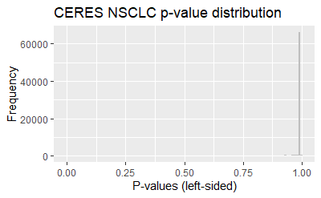

```r
# Plot p-value distribution
ggplot(data.frame(tmp), aes(x=value, fill=col)) +
  geom_histogram(bins=100) +
  scale_fill_manual(values = c("TRUE"="red", "FALSE"="gray")) +
  labs(title="CERES NSCLC p-value distribution",
       x="P-values (left-sided)",
       y="Frequency") +
  theme(legend.position="none")
```

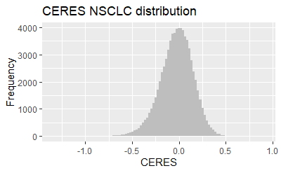

```r
# Plot CERES distribution
ggplot(tmp, aes(x=ceres, fill=col)) +
  geom_histogram(bins=100) +
  scale_fill_manual(values = c("TRUE"="red", "FALSE"="gray")) +
  labs(title="CERES NSCLC distribution",
       x="CERES",
       y="Frequency") +
  theme(legend.position="none")
```

# 6. A549-specific p-values

```r
a549_data$entrez = colnames(a549_ceres)[, 6:ncol(a549_ceres)]
```

[output not shown]